# R/qtl tutorial

Thom Nelson

2/20/2019

# R/qtl2

R/qtl2 can be installed directly from a CRAN-like repository that Karl Broman has set up.

Reading cross data into R works through a ‘control file’, which is a YAML document – [Yet Another Markup Language](https://yaml.org/) – containing some core info:

- files containing cross info
  - cross genotypes
  - cross phenotypes
  - phenotypic covariates (e.g. time of measurement)
  - genetic map
- Genotype designations in the genotype file
- Definitions of offspring sex
- Definition of cross design (e.g. f2)

# Input data formats

```r
id   , marker_1, marker_2, ... marker_k
indv1, 0       , 0       , ...        1
indv2, 1       , 1       , ...        2
...
indvN, 2       , -       , ...        1
```

### genetic map

```r
marker, chr, pos
m1    ,   1, 1.3
m2    ,   1, 3.4
m3    ,   1, 3.5
m4    ,   1, 6.0
...
mN    ,   C, XcM
```

### phenotypes

```r
id    , pheno1, pheno2, ... phenoK
indv1 ,   32.0,      N, ...      X
indv2 ,   14.6,      Y, ...      X
...
indvN ,    6.5,      N, ...      X
```

# Sample data and R objects

This document uses an F2-intercross “stigclos”, performed my Mariah McIntosh and Lila Fishman. The workflow and datasets are similar to those found in the [Rqtl2 tutorial](http://kbroman.org/qtl2/assets/vignettes/input_files.html).

You can first either set the working directory to the directory containing all files from my GitHub repo:

```r
setwd("/Users/thom/GitHub/tutorials/rqtl2/")
stigclos <- read_cross2("StigClos.yaml")
```

or simply point to the absolute path of that yaml file, e.g.:

```r
stigclos <- read_cross2("/Users/thom/GitHub/tutorials/rqtl2/StigClos.yaml")
```

The cross consists of 93 f2 offspring genotyped at 3367 markers on 14 linkage groups.

## The genetic map: genotypes & pseudomarkers

### calculate genotype probabilities

The genetic map is organized in the r/qtl2 object `stigclos` as a list of linkage groups. Access the entire map using `stigclos$gmap` or a specific linkage groups by `stigclos$gmap$lgname`. The linkage group name needs to be in back-quotes. For instance:

```r
head(stigclos$gmap$`1`)
```

```
##   scaffold_14|4613  scaffold_14|25273 scaffold_14|124909
##               0.00               1.08               1.61
## scaffold_14|158245 scaffold_14|326889 scaffold_14|128874
##               1.61               1.61               1.61
```

Then, insert pseudo-markers into the dataset. The `insert_pseudomarkers` function creates an object with the same structure as `stigclos$gmap` but contains a number of evenly spaced markers across the linkage group.

```r
map <- insert_pseudomarkers(stigclos$gmap, step=1)
head(map$`1`)
```

```
##   scaffold_14|4613            c1.loc1  scaffold_14|25273
##               0.00               1.00               1.08
## scaffold_14|124909 scaffold_14|158245 scaffold_14|326889
##               1.61               1.61               1.61
```

Next, calculate genotype probabilities at each pseudomarker. If working with a big-ass cross, you can specify the number of cores to use. Setting ‘cores=0’ will tell R/qtl2 to detect and use available cores via parallel::detectCores().

```r
pr <- calc_genoprob(stigclos, map, error_prob=0.002, cores = 2)
```

### kinship

You can use the genotype probabilities to construct a kinship matrix if you want to use a linear mixed model with a random polygenic effect:

```r
kinship <- calc_kinship(pr)
```

This creates a square matrix of kinship values for each pair of F2s. It’s easy to see that these are full sibs.

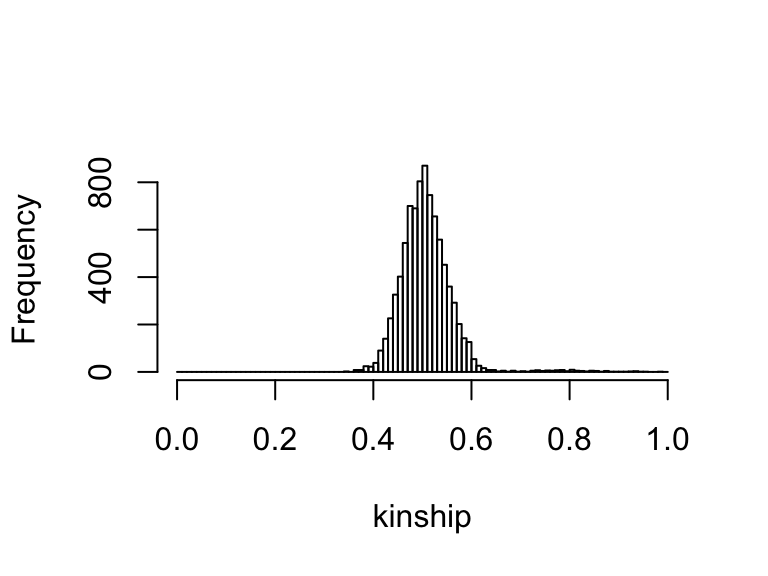

You may also wish to use the ‘leave one chromosome out’ (LOCO) method when conducting a genome scan. This method calculates kinship based on all but the focal chromosome. It can, therefore, be used in genome scans to compute QTL probabilities on a given chromosome conditional on kinship calculated on all the remaining chromsomes. As with calculating genotype probabilities, you may use multiple cores.

```r
kinship_loco <- calc_kinship(pr, "loco")
```

# Genome scans!

Perform a genome scan with Haley-Knott regression ([Haley & Knott 1992](https://www.ncbi.nlm.nih.gov/pubmed/16718932)) using the function `scan1()`. In the following genome scans, ‘CW’ stands for corolla width, which in this mapping population is a positive control with one major QTL and a few minor QTL.

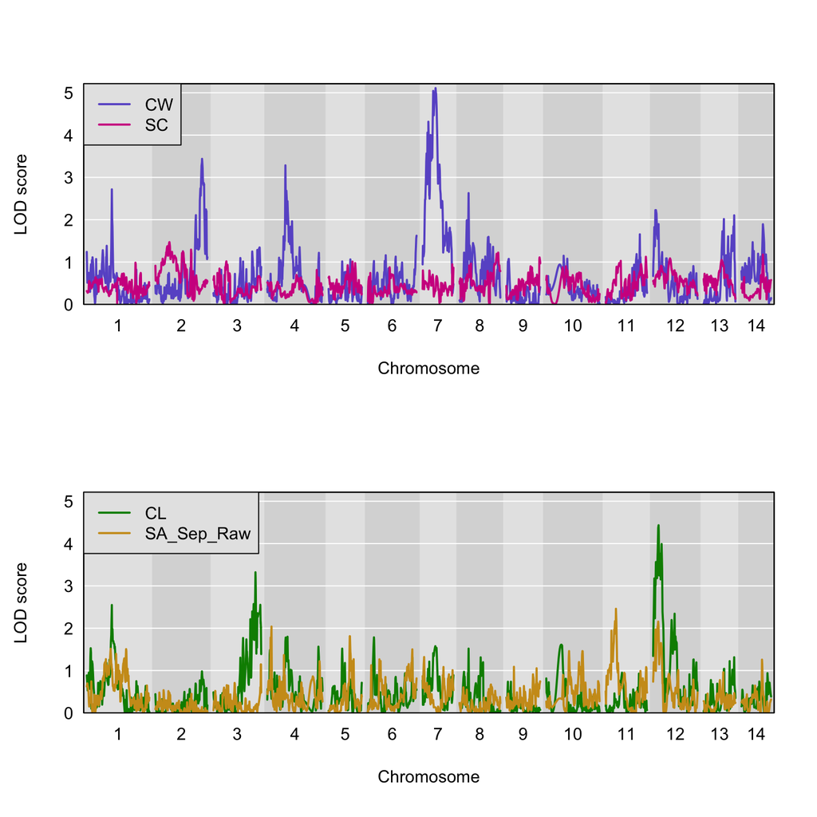

```r
scanout <- scan1(pr, stigclos$pheno, kinship = kinship_loco)

ymx <- maxlod(scanout) # overall maximum LOD score
phenocol <- 1
layout(matrix(1:4,2,1,byrow=T))
plot(scanout, map, lodcolumn=2, col="slateblue", ylim=c(0, ymx*1.02))
plot(scanout, map, lodcolumn=1, col="violetred", ylim=c(0, ymx*1.02),add=TRUE)
legend("topleft", lwd=2, col=c("slateblue","violetred"),
       colnames(scanout)[2:1], bg="gray90")
plot(scanout, map, lodcolumn=3, col="green4", ylim=c(0, ymx*1.02))
plot(scanout, map, lodcolumn=4, col="goldenrod3", ylim=c(0, ymx*1.02),add=TRUE)
legend("topleft", lwd=2, col=c("green4","goldenrod3"),
       colnames(scanout)[3:4], bg="gray90")
```